# Graphs in Python: Receiver Operating Characteristic Curves *without using axes objects*

⇦ Back

*This page only focuses on **plotting** ROC curves, not on how to do a full diagnostic accuracy analysis.*

# 1 Data

For this page we will use the Titanic dataset; a database of the passengers aboard the ill-fated Titanic passenger ship that sunk in 1912. Specifically, we will be asking the question:

> Can the amount of money a passenger paid for their ticket be used to predict whether or not they survived?

As such, the **fare** that they paid will be used as the *score* data and whether or not they **survived** (where `1 = survived` and `0 = died`) will be used as the *true* data.

The data can be downloaded from the Stanford website using Pandas:

```python
import pandas as pd

# Settings for displaying pandas data frames
pd.set_option('display.max_columns', 20)
pd.set_option('display.max_colwidth', 20)
pd.set_option('display.width', 1000)

# Download data
df = pd.read_csv('https://web.stanford.edu/class/archive/cs/cs109/cs109.1166/stuff/titanic.csv')
# Show data
print(df.head().to_html(index=False))
```

The first five rows look like this:

| Survived | Pclass | Name | Sex | Age | Sib/Spou | Par/Child | Fare |
| --- | --- | --- | --- | --- | --- | --- | --- |
| 0 | 3 | Mr. Owen Harris Braund | male | 22.0 | 1 | 0 | 7.2500 |
| 1 | 1 | Mrs. John Bradley (Florence Briggs Thayer) Cumings | female | 38.0 | 1 | 0 | 71.2833 |
| 1 | 3 | Miss. Laina Heikkinen | female | 26.0 | 0 | 0 | 7.9250 |
| 1 | 1 | Mrs. Jacques Heath (Lily May Peel) Futrelle | female | 35.0 | 1 | 0 | 53.1000 |
| 0 | 3 | Mr. William Henry Allen | male | 35.0 | 0 | 0 | 8.0500 |

# 2 Create ROC Curve from First Principles

First, import the necessary libraries and customise the settings you will use for all your plots:

```python
import matplotlib.pyplot as plt
import numpy as np

# Make images A6
A = 6
plt.rc('figure', figsize=[46.82 * .5**(.5 * A), 33.11 * .5**(.5 * A)])
# Use latex for the plot labels
plt.rc('text', usetex=True)
# Use a serif font for the plot labels
plt.rc('font', family='serif')
# Be able to use greek symbols in the plot labels
plt.rc('text.latex', preamble=r'\usepackage{textgreek}')
```

Next, extract the data you will be using to create the ROC curve from the data frame. In our case, the “Fare” is the score data and “Survived” is the truth/outcome data:

```python
# Extract the data of interest from the data frame
y = df['Survived'].values
score = df['Fare'].values
```

Next, initialise the variables that will be used for generating the plot:

- The true positive rates (sensitivity) will be plotted on the y-axis and the false positive rates (1-specificity) will be plotted on the x-axis
- The thresholds will be each of the cut-off values (for, in this case, ticket fare) for which true and false positive rate will be calculated. We can thus just use the fare prices themselves, plus 0, which guarantees that there will be no-one who paid less than the minimum threshold (as no-one paid less than 0) or more than the maximum threshold (as no-one paid more than the highest fare).
- The total number of positive outcomes (people who survived) and negative outcomes (people who died) is needed for calculating rate

```python
# Initialise the false positive rates
fpr = []
# Initialise the true positive rates
tpr = []
# Thresholds to iterate through
thresholds = [0] + sorted(score)
# Get the number of positive and negative results
P = sum(y)
N = len(y) - P
```

For each threshold (ie for each fare price), calculate the true positive rate and the false positive rate associated with using it as a cut-off for predicting survival:

```python
# Iterate through all thresholds and determine the fraction of true positives
# and false negatives found at every threshold
for threshold in thresholds:
    FP = 0
    TP = 0
    for i in range(len(score)):
        if (score[i] > threshold):
            if y[i] == 1:
                TP += 1
            if y[i] == 0:
                FP += 1
    fpr.append(FP / float(N))
    tpr.append(TP / float(P))
```

Convert the false positive rate into specificity (which is what is more usually plotted):

```python
# Get specificity from false positive rate
spec = [1 - x for x in fpr]
```

Use the trapezoidal rule to calculate the area under the curve:

```python
# Get the area under the curve from the trapezoidal rule (using Numpy)
AUC = -np.trapz(spec, tpr)
```

Now we can use Matplotlib to create the plot:

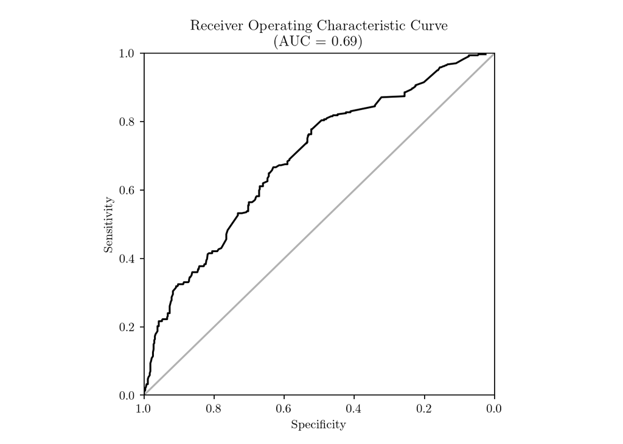

```python
#
# Plot
#
# Use an f-string to include the AUC in the title
plt.title('Receiver Operating Characteristic Curve\n' f'(AUC = {AUC:4.2})')
# Plot the ROC curve
plt.plot(spec, tpr, 'k-')
# Plot the diagonal line (be careful to not start at the origin)
plt.plot([1, 0], [0, 1], 'k-', alpha=0.3)
# Reverse the x-axis
plt.ylabel('Sensitivity')
plt.ylim([0, 1])
plt.xlabel('Specificity')
plt.xlim([1, 0])
# Make the plot square
plt.gca().set_aspect(abs(max(fpr) - min(fpr)) / abs(max(tpr) - min(tpr)))

plt.show()
```

# 3 Create ROC Curve Using scikit-learn

Now repeat the process using the functions provided by the `sklearn` package. This is not only quicker in terms of number of lines of code but it also runs quicker:

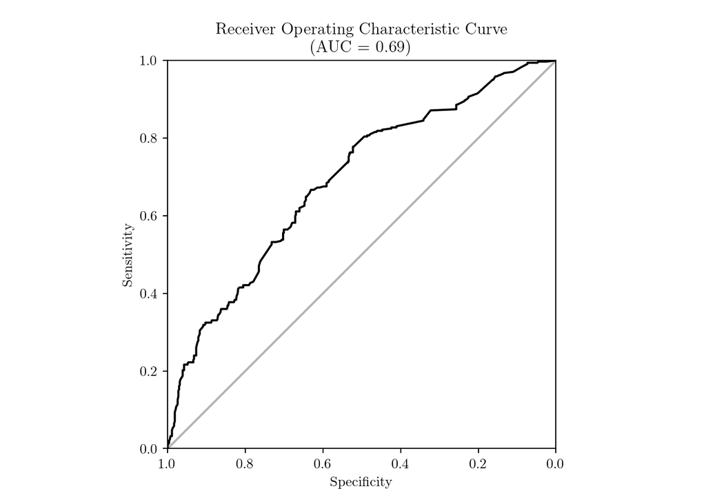

```python
import pandas as pd
import matplotlib.pyplot as plt
import sklearn.metrics as metrics

# Download data
df = pd.read_csv('https://web.stanford.edu/class/archive/cs/cs109/cs109.1166/stuff/titanic.csv')

# Extract the data of interest from the data frame
y = df['Survived'].values
score = df['Fare'].values
# Generate the false positive rates, true positive rates and thresholds
fpr, tpr, thresholds = metrics.roc_curve(y, score)
# Generate the area under the curve
# This is equivalent to auc = metrics.roc_auc_score(y, score)
auc = metrics.auc(fpr, tpr)
# Get specificity from false positive rate
spec = [1 - x for x in fpr]

#
# Plot
#
# Use an f-string to include the AUC in the title
plt.title('Receiver Operating Characteristic Curve\n' f'(AUC = {AUC:4.2})')
# Plot the ROC curve
plt.plot(spec, tpr, 'k-')
# Plot the diagonal line (be careful to not start at the origin)
plt.plot([1, 0], [0, 1], 'k-', alpha=0.3)
# Reverse the x-axis
plt.ylabel('Sensitivity')
plt.ylim([0, 1])
plt.xlabel('Specificity')
plt.xlim([1, 0])
# Make the plot square
plt.gca().set_aspect(abs(max(fpr) - min(fpr)) / abs(max(tpr) - min(tpr)))

plt.show()
```

⇦ Back